# Análise da precisão

```r
library(tidyverse)
library(here)
library(modelr)
library(broom)
theme_set(theme_bw())
```

## Os dados

```r
reclamacoes = read_csv(here("data/3-avaliacao-humana/reclamacoes-avaliadas-20190515.csv"))
reclamacoes = reclamacoes %>%
            select(id, orgao, data, titulo, texto, grupo_avaliando = 'Grupo que vai avaliar', insatisfacao, avaliadores, range.avaliacoes)


sentimentos = read_csv(here("data/5-sentimentos/sentimento2019.csv"))
reclamacoes <- reclamacoes %>% mutate(comprimento_titulo = str_length(titulo))
reclamacoes = reclamacoes %>% mutate(comprimento_reclamacao = str_length(texto))
```

`reclamacoes_l` tem um formato long em vez de wide (explicado [aqui](https://sejdemyr.github.io/r-tutorials/basics/wide-and-long/)).

```r
reclamacoes = reclamacoes %>%
    left_join(sentimentos, by = "id")


reclamacoes_l = reclamacoes %>%
    select(-palavras_op30, -palavras_sent, -grupo_avaliando) %>%
    gather(key = "lexico",
           value = "polaridade",
           sentimento_op30, sentimento_sent)
```

Funções usada durante o projeto

```r
normaliza = function(lexico, polaridade) {
    if(lexico == "sentimento_op30"){
        return ((((polaridade - minimo_op30)/(maximo_op30 - minimo_op30)) * -4) + 5)
    } else {
        return ((((polaridade - minimo_sent)/(maximo_sent - minimo_sent)) * -4) + 5)
    }
}
```

Converte polaridades para escala 1-5

```r
maximo_op30 = max(sentimentos %>%  select(sentimento_op30))
minimo_op30 = min(sentimentos %>%  select(sentimento_op30))
maximo_sent = max(sentimentos %>%   select(sentimento_sent))
minimo_sent = min(sentimentos %>%   select(sentimento_sent))

# Faça você mesmo. Crie a variável polaridade_normalizada

reclamacoes_polarizada = reclamacoes_l %>%
     mutate(polaridade_normalizada = normaliza(lexico, polaridade))
```

```
a condição tem comprimento > 1 e somente o primeiro elemento será usado
```

Calcula o erro (SSE) por reclamação. (Erro quadático).

```r
reclamacoes_polarizada = reclamacoes_polarizada %>%
    mutate(erro = (insatisfacao - polaridade_normalizada) ** 2 )
```

## EDA

Inicial. Faça os gráficos a mais que achar necessário para entender os dados que temos de resultado. Lembrando de nossa questão: Quão eficazes são os métodos de análise de sentimento baseados em léxicos para estimar o nível de insatisfação de reclamações recebidas pelo reclameaqui do governo federal? Existe um exemplo de EDA no repositório. Uma decisão importante a ser usada é se vamos considerar as avaliações humanas onde houve muita discordância sobre o nível de insatisfação.

### Questionamentos:

1. Há diferença no tamanho da reclamação por cada órgão?

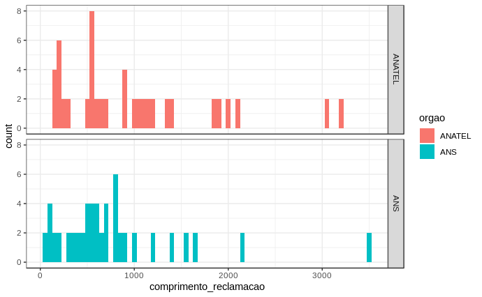

```r
reclamacoes_polarizada %>%
  filter(complete.cases(.)) %>%
  ggplot(aes(fill = orgao, x = comprimento_reclamacao), na.rm = TRUE) +
  geom_histogram(binwidth = 50, na.rm = TRUE) +
  facet_grid(orgao ~ .)
```

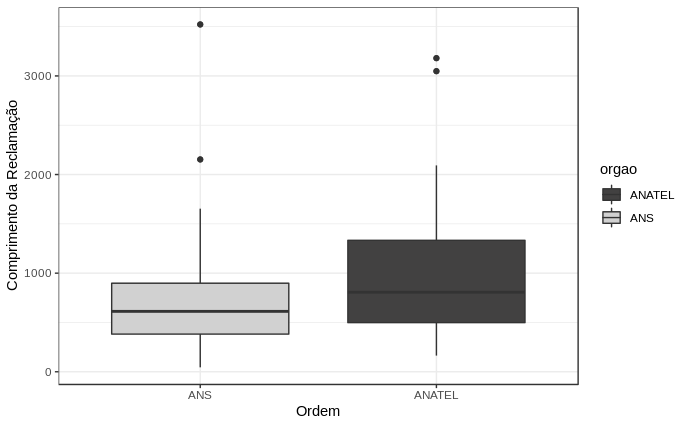

```r
reclamacoes_polarizada %>% group_by(orgao) %>%
  ggplot(aes(x = reorder(orgao, comprimento_reclamacao), y=comprimento_reclamacao)) + geom_boxplot(aes(fill=orgao)) + scale_fill_manual(values=c("#424141", "#d1d1d1")) + labs(x="Ordem", y = "Comprimento da Reclamação")
```

```r
reclamacoes_anatel <- reclamacoes_polarizada %>% filter(orgao=="ANATEL")
reclamacoes_ans <- reclamacoes_polarizada %>% filter(orgao=="ANS")

mean(reclamacoes_anatel$comprimento_reclamacao)
```

```
[1] 1013.7
```

```r
mean(reclamacoes_ans$comprimento_reclamacao)
```

```
[1] 798.9333
```

```r
wilcox.test(reclamacoes_anatel$comprimento_reclamacao, reclamacoes_ans$comprimento_reclamacao, paired = TRUE)
```

```
    Wilcoxon signed rank test with continuity correction

data:  reclamacoes_anatel$comprimento_reclamacao and reclamacoes_ans$comprimento_reclamacao
V = 1122, p-value = 0.1284
alternative hypothesis: true location shift is not equal to 0
```

Observando os gráficos gerados é possível ver que há uma pequena diferença dos tamanhos das reclamações por órgão. A ANATEL, em média, tem as reclamações com maior descrição.

2. Os tamanhos das reclamações ou títulos têm alguma relação com o nível de insatisfação de acordo com o tipo de avaliação (Humana, sent, op30)?

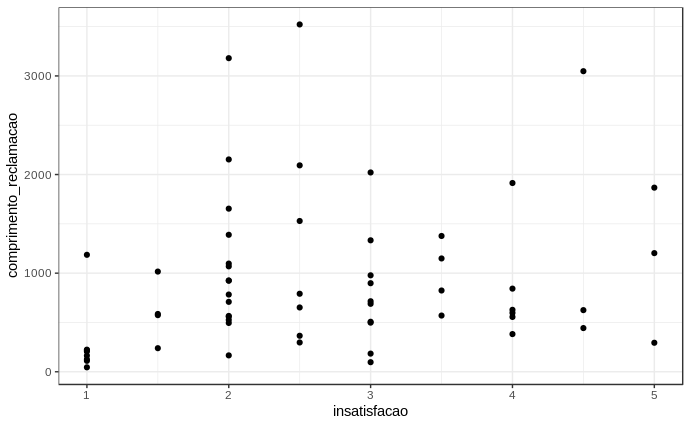

```r
reclamacoes %>% ggplot(aes(x = insatisfacao, y = comprimento_reclamacao)) + geom_point()
```

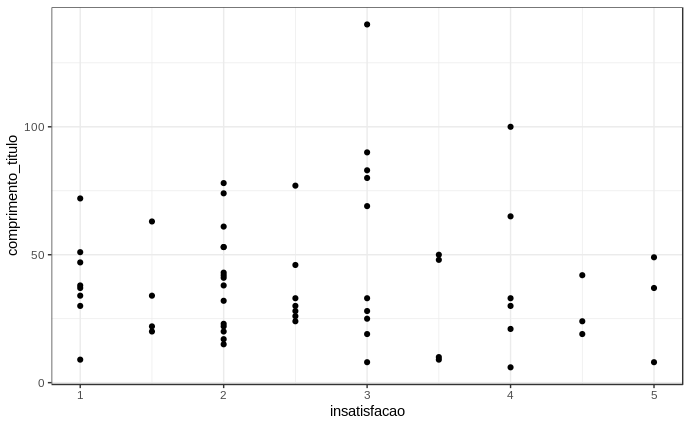

```r
reclamacoes %>% ggplot(aes(x = insatisfacao, y= comprimento_titulo)) + geom_point()
```

```r
normalizado_sent = reclamacoes %>%
    select(id,data, sentimento_sent, comprimento_reclamacao, comprimento_titulo) %>%
    mutate(normalizada_sent = normaliza("sentimento_sent", sentimento_sent))

normalizado_op30 = reclamacoes %>%
    select(id,data, sentimento_op30, comprimento_reclamacao, comprimento_titulo) %>%
    mutate(normalizada_op30 = normaliza("sentimento_op30", sentimento_op30))
```

# Analise de correlação entre os comprimentos dos títulos das reclamações e os níveis de insatisfação dependendo do método de avaliação

```r
par(mfrow = c(2,2))
plot(reclamacoes_polarizada$comprimento_titulo ~ reclamacoes_polarizada$insatisfacao)
plot(normalizado_sent$comprimento_titulo ~ normalizado_sent$normalizada_sent)
```

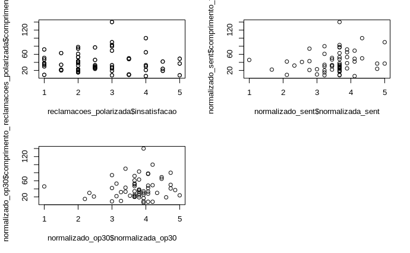

```r
plot(normalizado_op30$comprimento_titulo ~ normalizado_op30$normalizada_op30)
```

```r
cor.test(reclamacoes_polarizada$comprimento_titulo, reclamacoes_polarizada$insatisfacao, method='spearman')
```

```
Impossível calcular o valor exato de p com empates
```

```
    Spearman's rank correlation rho

data:  reclamacoes_polarizada$comprimento_titulo and reclamacoes_polarizada$insatisfacao
S = 313150, p-value = 0.3426
alternative hypothesis: true rho is not equal to 0
sample estimates:
        rho
-0.08739029
```

```r
cor.test(normalizado_sent$comprimento_titulo, normalizado_sent$normalizada_sent, method='spearman')
```

```
Impossível calcular o valor exato de p com empates
```

```
    Spearman's rank correlation rho

data:  normalizado_sent$comprimento_titulo and normalizado_sent$normalizada_sent
S = 27289, p-value = 0.06274
alternative hypothesis: true rho is not equal to 0
sample estimates:
      rho
0.2417653
```

```r
cor.test(normalizado_op30$comprimento_titulo, normalizado_op30$normalizada_op30, method='spearman')
```

```
Impossível calcular o valor exato de p com empates
```

```
    Spearman's rank correlation rho

data:  normalizado_op30$comprimento_titulo and normalizado_op30$normalizada_op30
S = 31388, p-value = 0.3302
alternative hypothesis: true rho is not equal to 0
sample estimates:
      rho
0.1278813
```

# Analise de correlação entre os comprimentos das reclamações e os níveis de insatisfação dependendo do método de avaliação

```r
par(mfrow = c(2,2))
plot(reclamacoes_polarizada$comprimento_reclamacao ~ reclamacoes_polarizada$insatisfacao)
plot(normalizado_sent$comprimento_reclamacao ~ normalizado_sent$normalizada_sent)
```

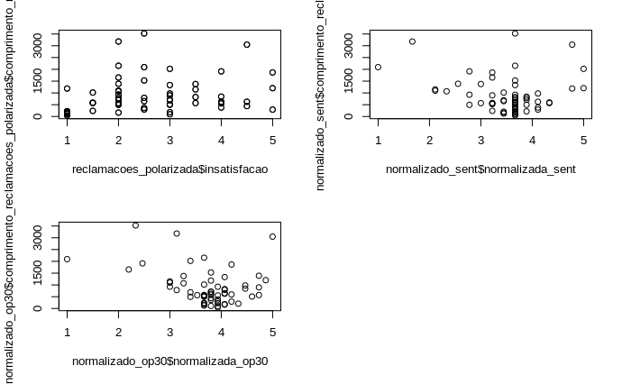

```r
plot(normalizado_op30$comprimento_reclamacao ~ normalizado_op30$normalizada_op30)
```

```r
cor.test(reclamacoes_polarizada$comprimento_reclamacao, reclamacoes_polarizada$insatisfacao, method='spearman')
```

```
Impossível calcular o valor exato de p com empates
```

```
    Spearman's rank correlation rho

data:  reclamacoes_polarizada$comprimento_reclamacao and reclamacoes_polarizada$insatisfacao
S = 208650, p-value = 0.002327
alternative hypothesis: true rho is not equal to 0
sample estimates:
      rho
0.2754556
```

```r
cor.test(normalizado_sent$comprimento_reclamacao, normalizado_sent$normalizada_sent, method='spearman')
```

```
Impossível calcular o valor exato de p com empates
```

```
    Spearman's rank correlation rho

data:  normalizado_sent$comprimento_reclamacao and normalizado_sent$normalizada_sent
S = 41491, p-value = 0.2436
alternative hypothesis: true rho is not equal to 0
sample estimates:
       rho
-0.1528521
```

```r
cor.test(normalizado_op30$comprimento_reclamacao, normalizado_op30$normalizada_op30, method='spearman')
```

```
Impossível calcular o valor exato de p com empates
```

```
    Spearman's rank correlation rho

data:  normalizado_op30$comprimento_reclamacao and normalizado_op30$normalizada_op30
S = 43874, p-value = 0.09265
alternative hypothesis: true rho is not equal to 0
sample estimates:
       rho
-0.2190524
```

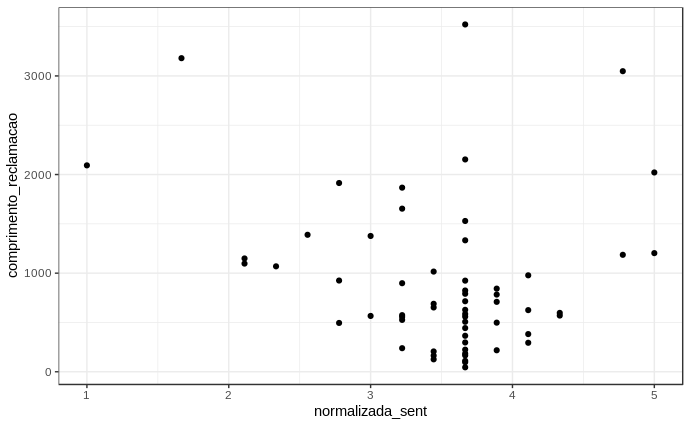

```r
## Gráficos que apresentam Avaliação gerada pelo sentimento normalizado(op30 ou sent) x Comprimento da descrição da reclamação
normalizado_sent %>%  ggplot(aes(x = normalizada_sent, y = comprimento_reclamacao)) + geom_point()
```

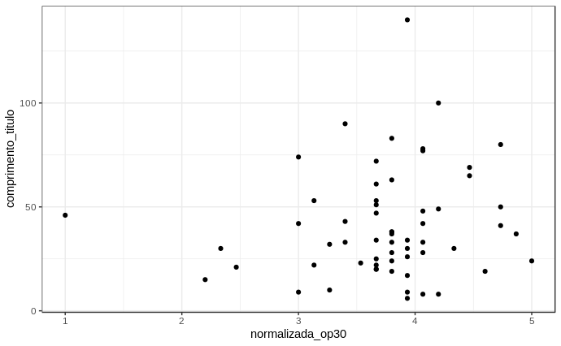

```r
normalizado_op30 %>% ggplot(aes(x = normalizada_op30, y= comprimento_titulo)) + geom_point()
```

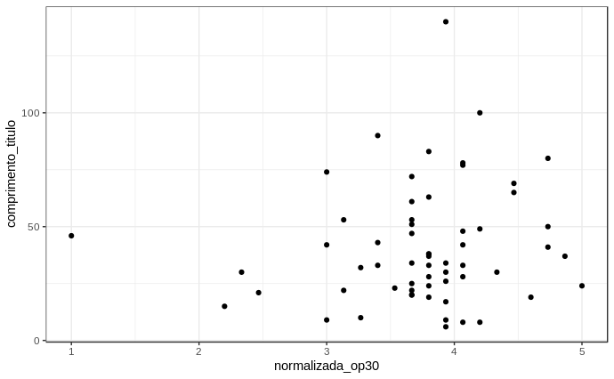

```r
normalizado_op30 %>% ggplot(aes(x = normalizada_op30, y= comprimento_titulo)) + geom_point()
```

3. Quais os dias na semana tiveram mais reclamações?

```r
renomeiaDias = function (data) {
  return (strsplit(data,", ")[[1]][1])
}
dias = reclamacoes %>% group_by(data) %>% summarise(dia = renomeiaDias(data),
                                                    insatisfacao = insatisfacao) %>% select(dia,insatisfacao)

diasOp30 = normalizado_op30 %>% group_by(data) %>% summarise(dia = renomeiaDias(data),
                                                    normalizada_op30 = normalizada_op30) %>% select(dia,normalizada_op30)

diasSent = normalizado_sent %>% group_by(data) %>% summarise(dia = renomeiaDias(data),
                                                    normalizada_sent = normalizada_sent) %>% select(dia,normalizada_sent)

mediaPorDia = dias %>% group_by(dia) %>% summarise(media = mean(insatisfacao))
mediaPorDiaOp30 = diasOp30 %>% group_by(dia) %>% summarise(media = mean(normalizada_op30))
mediaPorDiaSent = diasSent %>% group_by(dia) %>% summarise(media = mean(normalizada_sent))


numeroDias = dias %>% group_by(dia) %>% summarise(num = n())
```

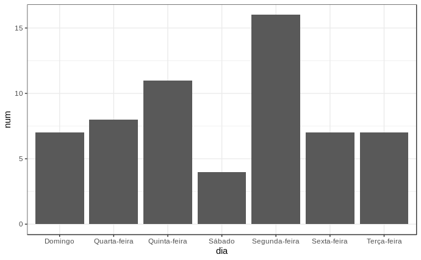

```r
numeroDias %>% ggplot(aes(x=dia, y=num)) + geom_bar(stat="identity")
```

Aqui podemos observar a frequência de reclamações ao longo do dia, podemos ver que o dia com mais reclamações é a segunda feira, agora vamos analisar em qual dia da semana temos as reclamações com maior nível de insatisfação fazendo a médias das reclamações diárias

4. o nível de insatisfação foi maior durante os finais de semana ?

[figure not shown]

```r
# Mediana por dia
medianaPorDia = dias %>% group_by(dia) %>% summarise(mediana = median(insatisfacao))
medianaPorDiaOp30 = diasOp30 %>% group_by(dia) %>% summarise(mediana = median(normalizada_op30))
medianaPorDiaSent = diasSent %>% group_by(dia) %>% summarise(mediana = median(normalizada_sent))

medianaPorDia
medianaPorDiaOp30
medianaPorDiaSent

par(mfrow = c(2,2))
medianaPorDia %>% ggplot(aes(x=dia, y=mediana)) + geom_bar(stat="identity")
medianaPorDiaOp30 %>% ggplot(aes(x=dia, y=mediana)) + geom_bar(stat="identity")
medianaPorDiaSent %>% ggplot(aes(x=dia, y=mediana)) + geom_bar(stat="identity")
```

[output not shown]

```r
# Usando o nível de insatisfacao por avaliação do op30
mediaPorDiaOp30 %>% ggplot(aes(x=dia, y=media)) + geom_bar(stat="identity")
```

[output not shown]

```r
# Usando o nível de insatisfacao por avaliação do sent
mediaPorDiaSent %>% ggplot(aes(x=dia, y=media)) + geom_bar(stat="identity")
```

[output not shown]

###Como avaliar a eficácia dos métodos?  
Uma medida interessante da eficiência desses métodos é calcular a soma dos erros ao quadrado (SSE) considerando o que o método definiu como a polaridade_normalizada e o que a avaliação humana definiu como a insatisfação.

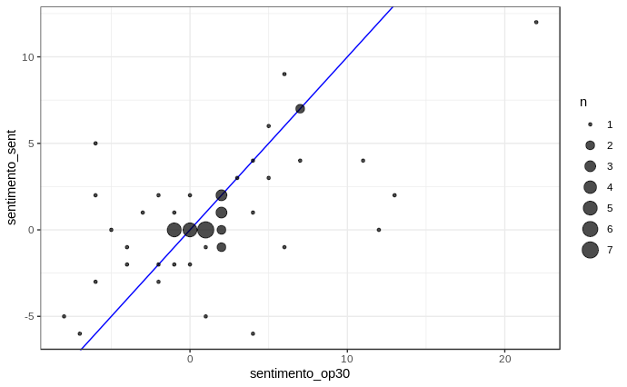

```r
reclamacoes %>%
    ggplot(aes(x = sentimento_op30, y = sentimento_sent)) +
    geom_abline(slope = 1, intercept = 0, color = "blue") +
    geom_count(alpha = .7)
```

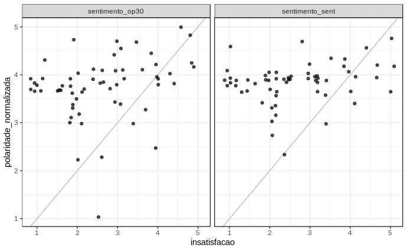

```r
reclamacoes_polarizada %>%
    ggplot(aes(x = insatisfacao, y = polaridade_normalizada, group = insatisfacao)) +
    geom_abline(slope = 1, intercept = 0, color = "grey") +
    geom_jitter(alpha = .7)  +
    facet_wrap(~ lexico)
```

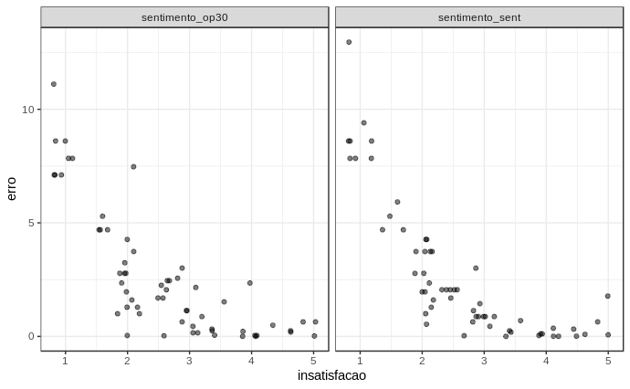

```r
reclamacoes_polarizada %>%
    ggplot(aes(x = insatisfacao, y = erro, group = insatisfacao)) +
    geom_jitter(alpha = .5)  +
    #geom_boxplot() +
    facet_wrap(~ lexico)
```

## Há relação entre o léxico e o erro?

Agora um modelo para responder sua pergunta.

```r
#Cria variável dummy para preditor categórico
reclamacoes_polarizada = reclamacoes_polarizada %>% mutate(lexico.dummy = if_else(lexico == "sentimento_sent", 1, 0))
#Você precisa entender o que fez acima para interpretar sua regressão
#Você pode também criar uma variável dummy para o órgao (se anac ou inss)
reclamacoes_polarizada = reclamacoes_polarizada %>% mutate(orgao.dummy = if_else(orgao == "ANS", 1, 0))
# ggpairs(reclamacoes_l %>% select(<selecione as colulas que vc quer usar aqui>))

# Modelos lineares para predizer o erro
# lexico
lm_erro_lexico = lm(erro ~ factor(lexico.dummy), data=reclamacoes_polarizada)
summary(lm_erro_lexico)

# lexico + comprimento reclamacao
lm_erro_lexico_compReclamacao = lm(erro ~ factor(lexico.dummy) + comprimento_reclamacao, data=reclamacoes_polarizada)
summary(lm_erro_lexico_compReclamacao)

# lexico + comprimento reclamacao + comprimento titulo
lm_erro_lexico_compReclamacao_compTitulo = lm(erro ~ factor(lexico.dummy) + comprimento_reclamacao + comprimento_titulo, data=reclamacoes_polarizada)
summary(lm_erro_lexico_compReclamacao_compTitulo)

# lexico + comprimento reclamacao + comprimento titulo + orgao
lm_erro_lexico_compReclamacao_compTitulo_orgao = lm(erro ~ factor(lexico.dummy) + comprimento_reclamacao + comprimento_titulo +  factor(orgao.dummy), data=reclamacoes_polarizada)
summary(lm_erro_lexico_compReclamacao_compTitulo_orgao)

# Modelos lineares para predizer a insatisfação
# lexico
lm_insatisfacao_lexico = lm(insatisfacao ~ factor(lexico.dummy) + factor(orgao.dummy) + comprimento_titulo + comprimento_reclamacao, data=reclamacoes_polarizada)
summary(lm_insatisfacao_lexico)

lm_insatisfacao = lm(insatisfacao ~ comprimento_reclamacao + erro + polaridade, data=reclamacoes_polarizada)
summary(lm_insatisfacao)

confint(lm_insatisfacao)

# Modelos para predizer a polaridade normalizada
lm_polaridade_normalizada = lm(polaridade_normalizada ~ comprimento_reclamacao + polaridade, data=reclamacoes_polarizada)
summary(lm_polaridade_normalizada)

reclamacoes_polarizada_sent = reclamacoes_polarizada %>%
  filter(lexico == "sentimento_sent")

reclamacoes_polarizada_op30 = reclamacoes_polarizada %>%
  filter(lexico == "sentimento_op30")

lm_polaridade_normalizada_sent = lm(polaridade_normalizada ~ comprimento_reclamacao + polaridade, data=reclamacoes_polarizada_sent)
summary(lm_polaridade_normalizada_sent)

lm_polaridade_normalizada_op30 = lm(polaridade_normalizada ~ comprimento_reclamacao + polaridade, data=reclamacoes_polarizada_op30)
summary(lm_polaridade_normalizada_op30)

confint(lm_polaridade_normalizada, level=.95)
```

[output not shown]

#verificando independencia dos preditores

```r
  cor.test( reclamacoes_polarizada$comprimento_reclamacao, reclamacoes_polarizada$erro, method="spearman")
  cor.test( reclamacoes_polarizada$comprimento_reclamacao, reclamacoes_polarizada$polaridade, method="spearman")

  cor.test( reclamacoes_polarizada$polaridade, reclamacoes_polarizada$erro, method="spearman")
```

[output not shown]